# Tidy Tuesday Extinct Plants

Mike Wehinger

18/08/2020

## Extinct Plant Visualization

The International Union for Conservation of Nature (IUCN) collects data on plants thought to be extinct. The data include 500 species that are either extinct or extinct in the wild. Those species extinct in the wild are still in cultivation centers such as botanical gardens.

There are 65 (13%) extinct in wild species and these may be considered ‘preserved’.

This visualization highlights the proportion of preserved species.

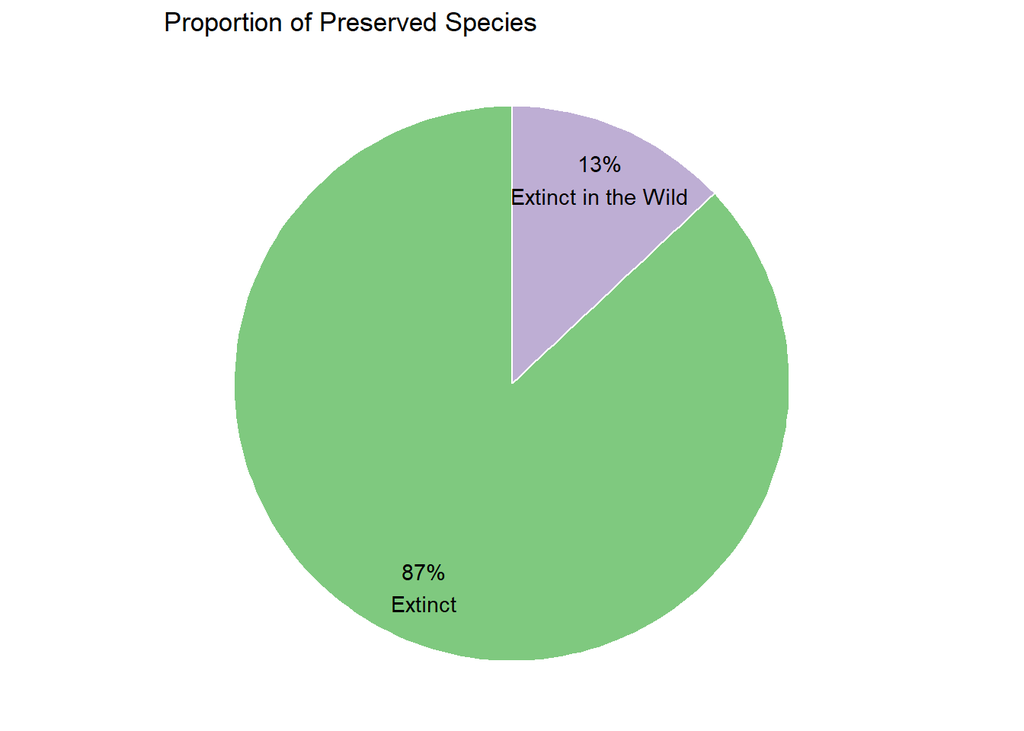

## Heatmaps

The objective is to show which plant groups are extinct and what proportion of them are preserved by continent.

The heatmap uses color to show which plant groups have an extinction by country of origin. The percent value shows what proportion of plant species have been preserved.

**The proportion of extinct plant species still in cultivation centers such as botanical gardens**

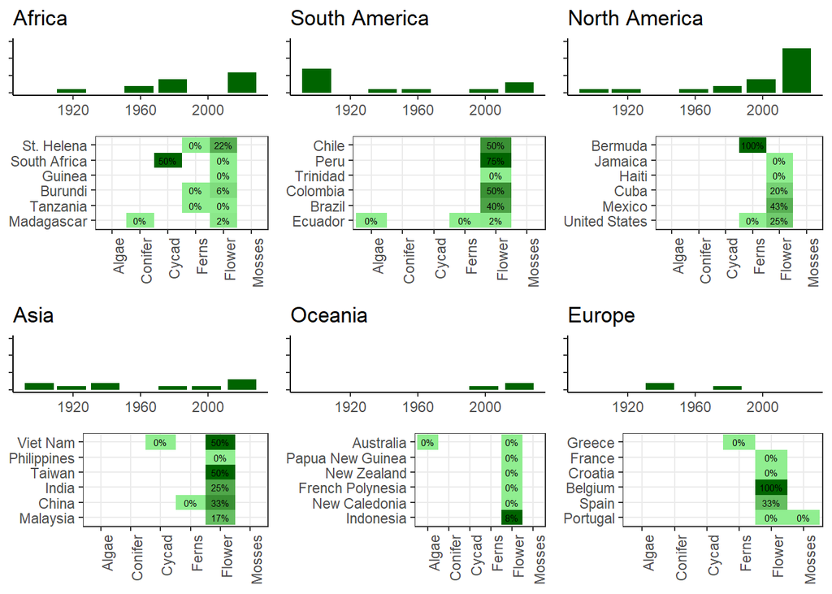

Observations

- Flowering plants are observed as extinct across all continents and many of these are preserved in some way
- **Cycads** are more prominent in South Africa with 50% of extinct species cultivated in conservation centers
- Bermuda is preserving **ferns**

## Chi Squared Test

Observed

|  | Extinct | Extinct in the Wild |
| --- | --- | --- |
| Algae | 3 | 0 |
| Conifer | 1 | 0 |
| Cycad | 4 | 4 |
| Ferns | 12 | 1 |
| Flower | 411 | 60 |
| Mosses | 4 | 0 |

Expected

|  | Extinct | Extinct in the Wild |
| --- | --- | --- |
| Algae | 2.61 | 0.39 |
| Conifer | 0.87 | 0.13 |
| Cycad | 6.96 | 1.04 |
| Ferns | 11.31 | 1.69 |
| Flower | 409.77 | 61.23 |
| Mosses | 3.48 | 0.52 |

Residuals

|  | Extinct | Extinct in the Wild |
| --- | --- | --- |
| Algae | 0.241 | -0.624 |
| Conifer | 0.139 | -0.361 |
| Cycad | -1.122 | 2.903 |
| Ferns | 0.205 | -0.531 |
| Flower | 0.061 | -0.157 |
| Mosses | 0.279 | -0.721 |

% contribution to test statistic

|  | Extinct | Extinct in the Wild |
| --- | --- | --- |
| Algae | 0.519 | 3.473 |
| Conifer | 0.173 | 1.158 |
| Cycad | 11.209 | 75.012 |
| Ferns | 0.375 | 2.508 |
| Flower | 0.033 | 0.220 |
| Mosses | 0.692 | 4.630 |